# Toward sustainable seaweed aquaculture: delphinid occurrence at macroalgae farms in the Carribean Sea

Amy M. Van Cise<sup>1*</sup>, Mollie Ball<sup>1</sup>, Clifford Goudey<sup>2</sup>, Gretchen Grebe<sup>2</sup>, Luis R. Rodriguez<sup>3</sup>, Loretta Roberson<sup>2</sup>

1. School of Aquatic and Fishery Sciences, University of Washington, Seattle, WA
2. Marine Biological Laboratory, University of Chicago, Woods Hole, MA
3. Department of Marine Sciences, University of Puerto Rico Mayagüez, La Parguera, PR

*Corresponding author email: avancise@gmail.com

Running page head: *Dolphin occurrence at algae farms*

## ABSTRACT

Global development of macroalgae farms is rapidly increasing due to growing demand for macroalgae in food, biofuel, cosmetic, and scientific markets, among others. The development of tropical macroalgal farms within the U.S. EEZ is a promising sector of economic growth, especially for small island economies such as Puerto Rico. However, the development of these farms increases risk to marine mammals and other protected species, and may lead to negative outcomes such as habitat exclusion, behavioral alteration, or entanglement. Acoustic monitoring was conducted during the development of two small-scale macroalgae farms off the coast of La Parguera, Puerto Rico by recording and analyzing data for approximately 10 days of every month between Jan 2021 - Jan 2024. Delphinids were consistently detected at the farm in approximately 1% of the analyzed data; the greatest rate of occurrence was detected at the Romero farm site early in the study period. We found that delphinid probability of detection was significantly affected by farm location, as well as season (Julian Date) and diel cycle (proximity to sunrise/sunset) with differing patterns at each farm location. Occurrence at farms increased significantly with proximity to sunrise or sunset, indicating crepuscular activity in nearshore delphinids. The results of this research illustrate that delphinids occurred near the taut-line marcoalgae farm structures used in this study without evidence of entanglement, and that entanglement risk may vary on a diel and seasonal basis with varying animal behavior. However, future work is required to determine whether placement of the farm structures caused a change of habitat use or behavior at either site.

Key Words: marine mammal monitoring, entanglement, macroalgae, biofuels, aquaculture

## INTRODUCTION

Global aquaculture production has increased rapidly in the 21st century, reaching 130.9 million tons in 2022 [1]. Algae comprised 36.5 million tons of the production, worth USD$17 billion, - more than 99% of this production occurs in Asia. Aquaculture is a major component of the United Nations 2030 Agenda for Sustainable Development, and is targeted by several global initiatives aimed at increasing sustainable aquaculture (e.g. U.N. Decade of Ocean Science for Sustainable Development, U.N. Blue Transformation Roadmap; [1]). These initiatives are expected to catalyze future aquaculture growth and expansion into new territory, e.g., offshore aquaculture.

Carrageenan-rich macroalgae, especially *Euchema* spp. and *Gracilaria* spp., are increasingly harvested for use in food production, synthetics, and biofuels [2,3] with a market value over $850 million in 2022 (projected $1.32 billion by 2030; [4]), motivating the development of warm-water macroalgae farms within the United States Exclusive Economic Zone (EEZ). The potential economic effect of macroalgae farms may be significant, especially to small island economies such as Puerto Rico and Caribbean nations, which rely heavily on marine resources and are increasingly threatened by pollution, climate change, fishing pressure, and loss of tourism revenue ([5]. In addition to economic benefits, coastal algal farms may reduce coastal erosion, mitigate eutrophication, and provide new habitat for local wildlife [6–8].

As aquaculture production continues to expand, maintaining the sustainability of these resources is a primary concern for world leaders - including mitigating and minimizing harmful impacts such as entanglement or habitat exclusion of protected species. Nearshore macroalgae farms are considered to be an environmentally sustainable business model, with little-to-no adverse effect on the local environment and potential benefits to the local economy, and the potential for positive environmental effects such as the creation of new habitat for fishes and marine invertebrates [e.g. 9]. However, experts recognize that the potential for sustainable seaweed farming can only be attained with effective monitoring and mitigation of negative impacts, particularly to marine organisms utilizing the same habitat [10], and some studies indicate that scaling up to a global level may have greater negative impacts and fewer positive impacts [11]. Despite significant growth in macroalgae farming, rigorous testing of marine mammal occurrence at and interaction with macroalgal farm structures is rare or nonexistent.

A recent review of peer-review literature, technical memoranda, and white papers documenting marine mammal interactions with finfish and mollusck aquaculture [12] concluded that aquaculture risk to marine mammals fall primarily into three categories: habitat exclusion, entanglement, and behavioral alteration such as attraction [13–21]. Similarly, farm avoidance has been reported in multiple studies of mollusk aquaculture [22–28], indicating that farm structure impacts are likely to include habitat exclusion and behavioral alteration. The extent and effect of habitat exclusion will depend on the size, concentration, and location of farms [15,29], which may impact a species or population if the excluded habitat comprises regions important to breeding, foraging, raising young, or resting [12,26,30].

Although existing research indicates avoidance behaviors are more likely than attraction around aquaculture infrastructure, marine herbivores (i.e., manatees) may be attracted to nearshore macroalgae farms for food and fish-eating marine mammals may be attracted to fishes aggregated by farming structures [31,32]. Marine mammals that directly interact with farm structures risk entanglement or entrapment in slack or loose anchor lines, horizontal longlines, and surface buoy markers [19]. Globally, entanglement in aquaculture gear is uncommon and unlikely to significantly impact marine mammals [12]; however, the impact of entanglements on specific populations may be significant if those populations are endangered, or if the concentration of farms increases in important feeding, breeding, or resting habitat [12].

Approximately 30 marine mammals inhabit the Caribbean; six of the baleen whales are observed very rarely [16,33]. Most regular inhabitants are toothed whales, as well as two baleen whales, three beaked whales, and one manatee species. No pinnipeds currently inhabit the Caribbean. Pantropical spotted dolphins (*Stenella attenuata*) are the most common marine mammal in abundance. Nearshore waters are frequented by three delphinid species: common bottlenose dolphins (*Tursiops trucatus*, hereafter bottlenose dolphins), Atlantic spotted dolphins (*Stenella frontalis*), and the endangered Antillean manatee (*Trichechus manatus manatus*, hereafter manatee). The endangered North Atlantic right whale (*Eubalaena glacialis*) is also an occasional visitor to the region.

In this study, we provide the first assessment of delphinid occurrence and risk of entanglement in coastal tropical macroalgae farms by quantifying delphinid occurrence at two macroalgae farms developed off the southwest coast of Puerto Rico (Figure 1) using acoustic detections of echolocation clicks. We define occurrence at the farm as detection within 15m of the acoustic recorder, and primarily aim to determine whether delphinid occurrence at the farm is correlated with visual observation of entanglements or evidence of entanglement (e.g., damage to farm structure or biomass) during the study period. In addition to this, we examine diel, seasonal, annual, and location-based trends in rate and duration of occurrence at each farm in order to provide further insight regarding risk of entanglement, habitat exclusion, or behavioral alteration caused by nearshore macroalgae farms.

## METHODS

### Data collection

We collected acoustic recordings at two nearshore farm development sites off the southwestern coast of Puerto Rico, nearest to La Paguera: Romero and Media Luna reefs (Figure 1). We deployed two farm types over the course of the experiment: a 3m x 61m 5-line farm (Romero) and a 33m x 61m, 20-line catenary farm (Media Luna; Supplemental Figure S1). Bottlenose dolphins are the only marine mammal considered likely to interact with farms at these locations. While uncommon, manatees do visit reefs near each of the farm sites; however, satellite tracking data indicates a low probability that manatees pass through the farm locations en route to nearby reefs (D. Sloane, USGS, *pers. comm.*).

We recorded acoustic signals using a SoundTrap ST300 STD acoustic recorder (Ocean Instruments, Inc.) mounted to the SE corner of the farm structure. The recording package has an effective frequency range of 20 Hz - 60 kHz, noise floor less than 35 dB re 1 μPa above 2 kHz, and a sample rate up to 288 kHz. We set sampling rate at 96 kHz and recording effort to a duty-cycle of 1:5 minutes, allowing for a deployment duration of up to approximately 50 days between recorder servicing. Generally, the recorder was collected, serviced, and re-deployed monthly throughout the study period. Once data were downloaded to an external hard drive, they were shipped to the University of Washington for acoustic processing.

In addition to acoustic data collection, we visited each farm site approximately weekly for regular maintenance of the farm infrastructure and equipment. Data logs from these visits included records of visual observations of protected species (marine mammals or turtles). We also inspected the farm for visual signs of damage, e.g. damage to the taut-line infrastructure or algal biomass, that may be indicative of entanglement or interaction.

### Acoutic data processing

We first divided acoustic data into monthly bins, then conducted an initial automated detection step using PAMGUARD [35,36], an open-source software package developed for detection and classification of acoustic signals from marine mammals. Using the click detection module in PAMGUARD, we built an algorithm to categorize potential clicks into three categories: 4-15 kHz clicks with a frequency sweep (unlikely delphinid click), 15-45 kHz signals with a frequency sweep (likely bottlenose dolphin clicks), and all other unclassified detections. These signal categories were developed based on the reported frequency range of bottlenose dolphins [38], the target species of interest and species most likely to interact with the farm.

In addition to automated click detection, we used the PAMGUARD whistle and moan detector to detect tonal signals produced by marine mammals [39]. After preliminary filtering of detections that were unlikely to be calls from manatees or delphinids, i.e. detections with maximum frequency lower than 2kHz and duration less than 0.1 seconds [40,41], the number of detections of tonal calls was negligible in size. Therefore, we did not include this data in downstream analysis of marine mammal occurrence at the farm.

Following click automated detection, we conducted a visual validation of the detection data in 1-minute bins to filter out false positive detections. We first removed 4-15 kHz detections and unclassified detections, which do not have the acoustic characteristics of delphinid echolocation clicks. Next, examining only detections in the 15-45 kHz range, we distinguished and annotated delphinid clicks from ambient noise by scanning detections to identify multiple signals in rapid succession with similar waveforms, spectra, and wigner plots, most often increasing and then decreasing in amplitude as individuals swept directional click trains across the recording package (Supplemental Figure S2). All annotated clicks occurring within the same 1-minute recording period were grouped together and given a click event ID.

Due to the prevalence of environmental noise in the data set and the lack of an existing classifier for marine mammals in Puerto Rico or the Caribbean, click events were not formally classified to species; therefore, we refer to all detections as delphinids throughout this manuscript.

We filtered annotated click events to include only those events with > 10 clicks over 150 dB. To determine this threshold, we estimated the expected amplitude of received echolocation signals from delphinids near the farm (<15 m) using the sonar equation assuming geometric spreading and signal attenuation:

$$RL = SL - 20*log(r) + \alpha*r$$

### Data analysis

All data analyses and plots were generated using the R coding language in R studio [43]. To qualitatively examine shifts in the number or duration of occurrences at farms over the study period, we first grouped filtered click-positive minutes that occurred sequentially and estimated the normalized proportion of occurrences at each farm and in each month (# occurrences/# minutes monitoring effort). We also estimated duration of each occurrence, by calculating the time difference between the beginning of the first click event and the end of the last click event in the detection. Following this we used a generalized linear models (GLM) to test for trends in the normalized number or duration of occurence at either farm throughout the study period.

We then estimated binomial acoustic detection probability at each farm site using a generalized additive modeling (GAM) framework, implemented using mgcv in R [44]. We considered smoothed terms for seasonality (Julian Day) and diel cycle (proximity to sunrise/sunset), each factored by farm location, as potential drivers of detection probability. Factoring by farm location does not assume that the relationship between continuous input variables and detection probability is the same at both farm locations; instead, it allows fitted smoothing splines to vary within strata. We identified significant model covariates with a p-value < 0.05 and predicted detection probability using these covariates.

## RESULTS

Acoustic data were collected between January 2021 through January 2024 at two separate farm sites: data collection occurred at Romero in 2021 and 2022, and at Media Luna in 2022 - Jan 2024 (Figure 1). The Romero farm site was deployed on April 28, 2021 and removed on March 17, 2022. The Media Luna farm site was deployed on March 29, 2022 and removed April 28, 2024.

Visual observations of marine mammal presence at each farm were collected in tandem with diver inspection of the farm structure and biomass. Visits were made to Romero at a mean rate of 10 days (sd = 11 days) and to Media Luna at a mean rate of 7 days (sd = 11 days). In addition to this, a total of 11 visits were made to both farm sites before farm infrastructure was placed.

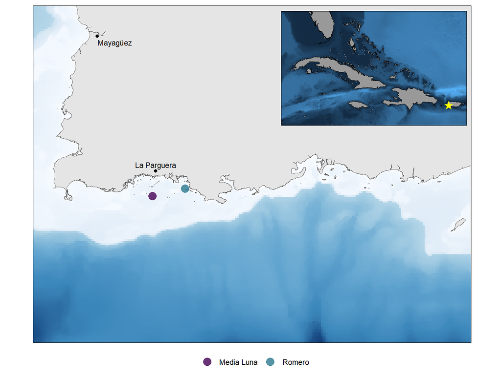

Figure 1. Location of the two farm sites used in this study, near the Romero and Media Luna reefs off the southwestern coast of Puerto Rico in the Caribbean.

### Monitoring for interaction or entanglement

No marine mammals were visually observed at either farm site before farm infrastructure was placed, but dolphins were acoustically detected at Romero during two short deployments of the recorder in January and February 2021, before the farm infrastructure was deployed.

Bottlenose dolphins were visually observed twice at the Romero farm site after farm (n = 24 visits), both during July 2021 following farm deployment in April. Bottlenose dolphins were visually observed at Media Luna a total of 5 times (n = 108 visits): October 2022, July, August, and October 2023, and April 2024. On two of these occasions, visual observers noted that the dolphins stopped travel and exhibited behaviors indicating curiosity about the farm structure and/or divers. Manatees were not visually observed at either farm site during the study period. A single sea turtle was visually observed at Media Luna in March of 2024.

Our acoustic dataset included 969 click-positive minutes, representing approximately 0.9% of the total dataset. Grouping sequential click-positive minutes resulted in 604 total detections of delphinid occurrence at both farms during the study period. Monthly recording effort and normalized number of delphinid occurrences per minute are shown in Figure 2.

When comparing visual and acoustic delphinid detections, we found that 5 of the 7 visual detections occurred when acoustic data were not being collected. The two visual detections that occurred when acoustic data were being collected coincided with acoustic detections on the same date: on October 12, 2022 there was one visual and one acoustic detection, and on October 29,2023 there were eight acoustic detections and one visual detection. Delphinids were acoustically detected on 12 days (Romero = 1 day, Media Luna = 11 days) coinciding with the remaining 136 visual inspections at both farms, where delphinids were not observed.

No damage to either farm infrastructure or biomass, or other evidence of entanglement, was observed during the study period. The remainder of the results provide detailed analysis of delphinid behavior and occurrence at the farm structure during the study period based on acoustic monitoring.

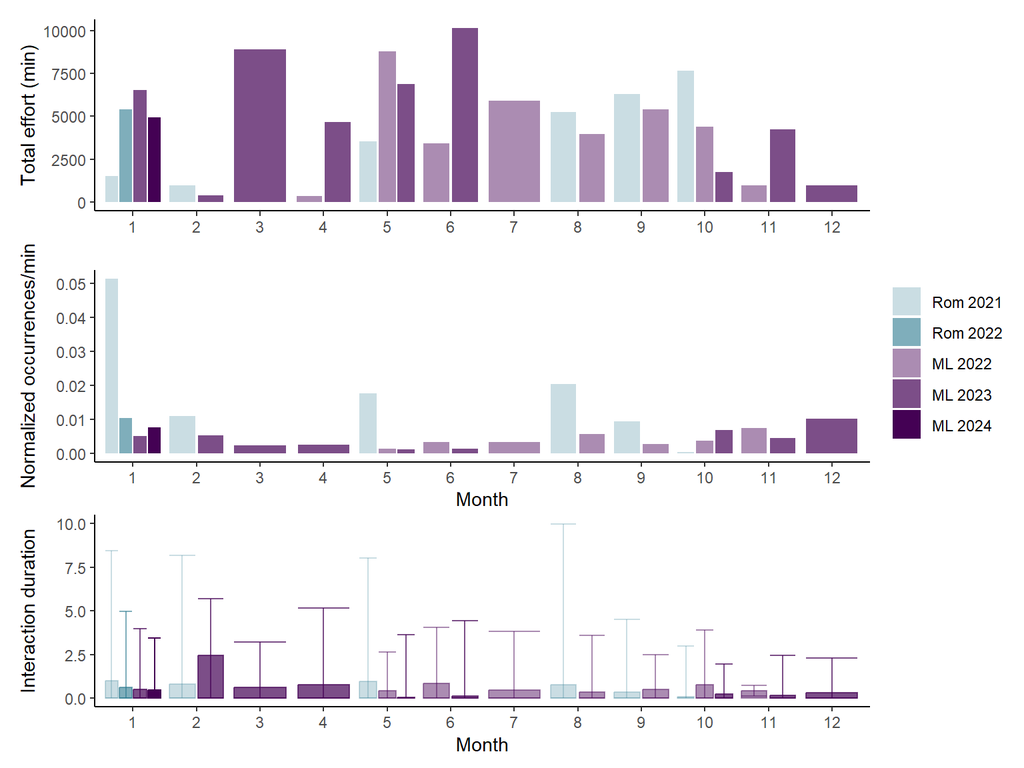

Figure 2. Top: Recording effort in each month and year at both farm sites. Middle: Number of occurrences/min in each month and year throughout the study period. Bottom: Duration of occurrences over the study period.

### Number and duration of acoustic delphinid occurrences

After normalizing for monthly recording effort, the number of acoustic occurrences/min was consistent over the study period (Figure 2), with notable outliers at the Romero farm site in January 2021 (before farm deployment) as well as May and August of 2021 (after farm deployment). The number of occurrences/min varied significantly between the two farm sites (p = 0.002, Figure 3), but did not vary significantly when the three outlier months were removed (p = 0.2)

The duration of delphinid occurrences at farms varied widely over the study period (Figure 2), ranging from 0 - 60.13 minutes, with a mean duration of 3.44 minutes (median = 0.64 minutes). Most occurrences were less than 1 minute in duration (n = 390 of the total 604 occurrences). Duration also varied significantly between farm sites (p = 0, Figure 3), driven by longer occurrence durations during early months at the Romero farm site (Figure 2).

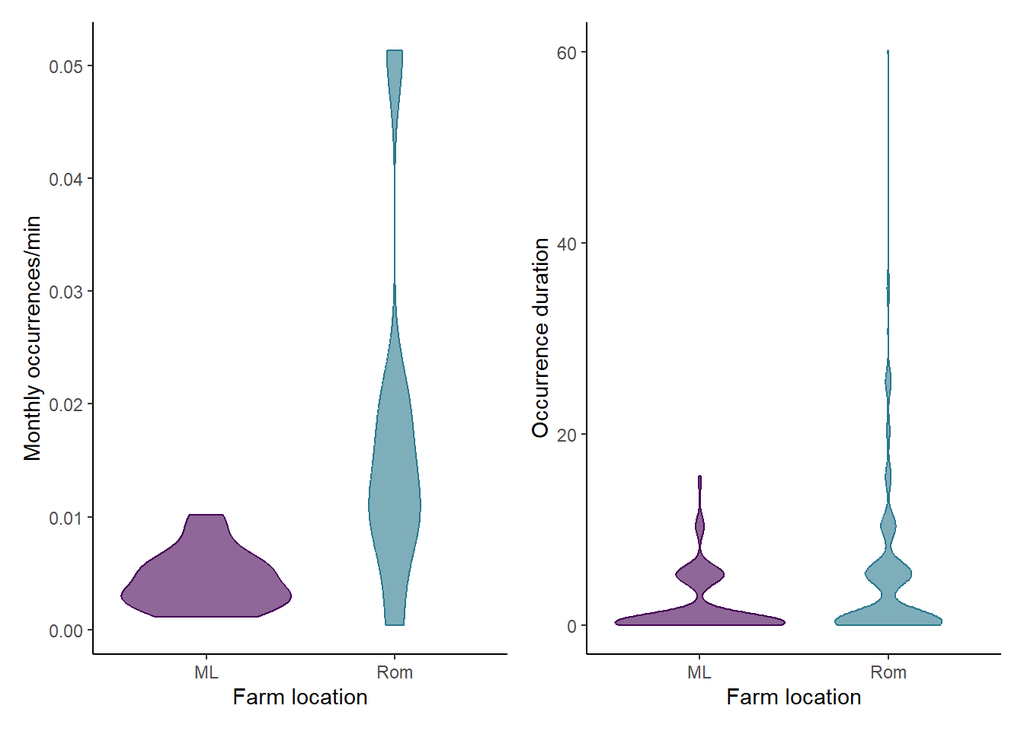

Figure 3. Monthly number of occurences/min (left) and duration of occurences (right) at each farm site.

### Diel and Seasonal variability in detection probability

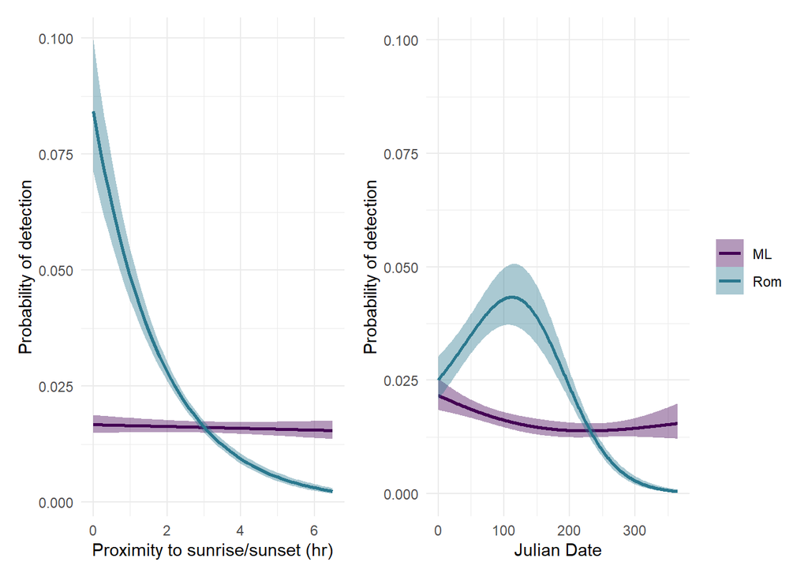

## DISCUSSION

### Acoustic monitoring of aquaculture farms

Here we demonstrate the efficacy of acoustic data collection to monitor long-term behavior of delphinids near aquaculture infrastructure. Delphinids occurred regularly at both farm sites between January 2021 and 2024, although infrequently for most of the study period. During that time, no entanglements were reported, and no damage to the farm structure or biomass - indicative of entanglements - was recorded during regular diver inspections of the farm. Most of the acoustic detections of delphinid occurrence at the farm were less than one minute long, indicating that delphinids were passing through the area and were not attracted to the farm structure. Over the same time period, bottlenose dolphins were visually observed 7 times near the farms - in 2 out of 7 of the visual observations, the delphinids remained near the farm for more than 10 minutes and exhibited curiosity towards divers or foraged nearby fishes.

Our results from three years of acoustic and visual monitoring indicate that delphinids may be able to safely interact with taut-line nearshore seaweed farms. Their ability to interact with farms of this type may be aided by their agility and echolocation, which increases their ability to perceive objects or obstacles in murky or dark conditions, as well as the taut-line farm structure developed to minimize entanglement risk. However, the results of our study are specific to the species involved, the region, and the specific type of macro-algae farm deployed. Further, this study does not quantitatively elucidate whether the placement of the farms elicited a behavioral response (i.e. attraction or avoidance) from nearshore delphinid populations.

A comprehensive understanding of the effects of nearshore macroalgae farms on entanglement risk, habitat use, and behavioral dynamics of marine mammal populations will require additional monitoring studies in varying conditions including ecosystem, marine mammal species assemblage, and farm type. The present study illustrates that acoustic monitoring is an effective tool for understanding delphinid occurrence at nearshore macroalgae farms, and provides a preliminary basis for comparison by future seaweed aquaculture monitoring studies.

It was not possible to acoustically monitor manatee presence during this study. This was due to a number of reasons: manatees do not produce echolocation clicks, only tonal whistles and moans. Whistle and moans were detected in very small numbers and therefore this data set was not included in downstream analyses. Further, there is not currently an available whistle and moan classifier that includes manatee vocalizations [39]; developing a classifier without visually validated vocalizations is not recommended and beyond the scope of this project.

### Delphinid behavior at macroalgae farms

Significantly more delphinid detections occurred at the Romero farm site than at the Media Luna site, most notably during the first month of the study, before initial farm deployment. Occurrence was lower in February, and increased again in May and August (following farm deployment in April). After August 2021, occurrence at Romero remained low for the duration of the study period. This observed pattern may have been caused by an initial pique of interest by delphinids passing through the area, as bottlenose dolphins are known to be curious. Their curiosity may increase entanglement risk at the onset of farm development if they approach the new structure to investigate and are unable to navigate subsurface lines. Alternatively, the relatively high occurrence of delphinids near the Romero farm site in January indicates that it may have already been a site that was heavily utilized by delphinids, e.g. as a resting or foraging ground or corridor for travel, and then were excluded from the site by the development of the farm. Behavioral exclusion has been observed in other aquaculture industries ([22–28] and would be considered a negative behavioral adaptation, especially if the farms are located in areas that are biologically important to the species. However, it is important to note that acoustic data collection in January 2021 was relatively small compared to other months, and its possible that the large proportion of acoustic detections may have been a result of sampling bias.

Behavioral avoidance or attraction at farm sites can be detected and quantified through comparison of baseline acoustic data collected before the farm is deployed. In the present study, we were largely prohibited from collecting baseline data due to permitting restrictions and COVID-related obstacles, which limits our ability to assess behavioral response to nearshore taut-line seaweed farms. We therefore recommend that future studies of marine mammal interactions with macroalgal farms should include the collection of baseline data at proposed farm sites for up to 12 months before deployment of the farm structure in order to facilitate the interpretation of patterns observed after the farm is deployed.

All acoustic monitoring was conducted while the farm supported low algal biomass. As biomass increases, it is likely to attract more fish, potentially increasing the presence of marine mammals. Anecdotal sightings of bottlenose dolphins and barracuda near the farm in early 2024 may reflect this trend and underscore the need for continued observation. Increased biomass could reduce the visual detectability of farm structures while adding weight to lines, requiring additional buoyancy support and potentially increasing the complexity and entanglement risk of the gear. Although odontocetes may still detect farm lines via echolocation, the risk to baleen whales, which rely less on echolocation and more on vision and tactile cues, remains a concern. Sound-reflective materials may improve detectability for odontocetes, but mitigation strategies for baleen whales are limited.

### Expanding aquaculture

As the aquaculture industry continues to grow, it becomes increasingly important to monitor entanglement risk for marine mammals and other threatened species, particularly in offshore expansion scenarios. Careful site selection, gear design, and ongoing monitoring are essential, especially when considering placing farms offshore or in regions with different marine mammal communities and environmental conditions. Acoustic or visual monitoring of marine mammal use of potential farm sites prior to placement of infrastructure will be essential to informing the selection of sites that are minimally utilized by these protected species. Several threatened or critically endangered baleen whales occupy offshore waters in the Caribbean, notably including the North Atlantic right whale [16,33,55]. Entanglement is a major threat to the recovery of these species [56,57]. While this study indicates that coastal delphinids may be able to interact safely with nearshore taut-line seaweed farms, there is little published data to suggest whether other species, particularly baleen whales, might be at risk of entanglement with similar taut-line macroalgal farm structures. Detection of baleen whales in the waters surrounding Puerto Rico is rare; nontheless, any development of offshore macroalgae farms should be accompanied by robust visual and acoustic surveys of baleen whale abundance before farm development. A successful macroalgae farm would be placed in a site that minimizes the likelihood of interactions with any protected species, and would be accompanied by regular monitoring to ensure early detection of any entanglements that do occur. Ideally, a real-time, automated acoustic monitoring and warning system, such as has been implemented for North Atlantic right whales in Cape Cod Bay [58], would be implemented alongside any farms deployed in offshore sites with high entanglement risk.

## CONCLUSION

Here we provide the first quantitative analysis of the rate of delphinid occurrence at nearshore taut-line macroalgae aquaculture structures, and demonstrate the effectiveness of acoustic monitoring of marine mammal occurrence near aquaculture infrastructure. Our results indicate that delphinids are able to safely occur at or near farm structures without entanglement; however, it is possible that these structures excluded delphinids from biologically important areas. We recommend that any future development of macroalgae farms include acoustic monitoring of marine mammal occurrence and behavior near the farm. In addition to monitoring delphinid activity at the farm, the studies should plan to collect data at the proposed farm site for a period of up to a year prior to the deployment of the farm in order to quantify and characterize delphinid presence and activity in the area. We further highlight diel and seasonal patterns in delphinid activity that suggest entanglement risk may vary over time. The results of this study may provide insight into the placement of new macroalgae farms in similar coastal ecosystems; however, we caution that the results are not applicable in ecosystems with different marine mammal species, and that endangered baleen whales living in offshore environments may be especially vulnerable to complex underwater structures such as macroalgae farms.

## REFERENCES

1.

FAO na. 2024 The state of world fisheries and aquaculture 2024 - Blue transformation in action. (doi:10.4060/cd0683en)

2.

Campbell R, Hotchkiss S. 2017 Carrageenan Industry Market Overview. In *Tropical Seaweed Farming Trends, Problems and Opportunities: Focus on Kappaphycus and Eucheuma of Commerce* (eds AQ Hurtado, AT Critchley, IC Neish), pp. 193–205. Cham: Springer International Publishing. (doi:10.1007/978-3-319-63498-2_13)

3.

FAO na. 2022 *The State of World Fisheries and Aquaculture 2022*. FAO. (doi:10.4060/cc0461en)

4.

Research and Markets. 2023 [Carrageenan Market Size](https://www.gminsights.com/industry-analysis/carrageenan-market).

5.

Clegg P, Mahon R, McConney P, Oxenford H. 2022 *The Caribbean Blue economy*. 1st edn. New York, NY: Routledge.

6.

Tanaka Y, Ashaari A, Mohamad FS, Lamit N. 2020 Bioremediation potential of tropical seaweeds in aquaculture: low-salinity tolerance, phosphorus content, and production of UV-absorbing compounds. *Aquaculture* **518**, 734853. (doi:10.1016/j.aquaculture.2019.734853)

7.

Theuerkauf SJ, Barrett LT, Alleway HK, Costa-Pierce BA, St. Gelais A, Jones RC. 2022 Habitat value of bivalve shellfish and seaweed aquaculture for fish and invertebrates: Pathways, synthesis and next steps. *Reviews in Aquaculture* **14**, 54–72. (doi:10.1111/raq.12584)

8.

Walls A, Kennedy R, Fitzgerald R, Blight A, Johnson M, Edwards M. 2016 Potential novel habitat created by holdfasts from cultivated Laminaria digitata: assessing the macroinvertebrate assemblages. *Aquacult. Environ. Interact.* **8**, 157–169. (doi:10.3354/aei00170)

9.

Spillias S *et al.* 2022 Expert perceptions of seaweed farming for sustainable development. *Journal of Cleaner Production* **368**, 133052. (doi:10.1016/j.jclepro.2022.133052)

10.

Kelly ELA, Cannon AL, Smith JE. 2020 Environmental impacts and implications of tropical carrageenophyte seaweed farming. *Conservation Biology* **34**, 326–337. (doi:10.1111/cobi.13462)

11.

Spillias S *et al.* 2023 The empirical evidence for the social-ecological impacts of seaweed farming. *PLOS Sustainability and Transformation* **2**, e0000042. (doi:10.1371/journal.pstr.0000042)

12.

Bath GE, Price CA, Riley KL, Morris Jr JA. 2023 A global review of protected species interactions with marine aquaculture. *Reviews in Aquaculture* **15**, 1686–1719. (doi:10.1111/raq.12811)

13.

Callier MD *et al.* 2018 Attraction and repulsion of mobile wild organisms to finfish and shellfish aquaculture: a review. *Reviews in Aquaculture* **10**, 924–949. (doi:10.1111/raq.12208)

14.

Carretta JV *et al.* 2020 U.S. Pacific Marine Mammal Stock Assessments : 2019. (doi:10.25923/trxr-z635)

15.

Clement D, Sagar P. 2013 Literature review of ecological effects of aquaculture: effects on marine mammals.

16.

Hayes SA(editor) *et al.* 2020 U.S. Atlantic and Gulf of Mexico marine mammal stock assessments - 2019. (doi:10.25923/ngsq-qc69)

17.

Lloyd B. 2003 Potential effects of mussel farming on New Zealand’s marine mammals and seabirds: a discussion paper.

18.

López BD. 2012 Bottlenose dolphins and aquaculture: interaction and site fidelity on the north-eastern coast of Sardinia (Italy). *Mar Biol* **159**, 2161–2172. (doi:10.1007/s00227-012-2002-x)

19.

Price CS, Morris JA (James Adiel), Jr, Keane EP, Morin DM, Vaccaro C, Bean DW(William) 1963-. 2017 [Protected species and marine aquaculture interactions. NOAA Technical Memorandum NOS NCCOS 211](https://repository.library.noaa.gov/view/noaa/16942).

20.

Pearson H, V-H, S, and Würsig B. 2012 Avoidance of mussel farms by dusky dolphins (Lagenorhynchus obscurus) in New Zealand. *New Zealand Journal of Marine and Freshwater Research* **46**, 567–574. (doi:10.1080/00288330.2012.712977)

21.

Díaz López B, Methion S. 2017 The impact of shellfish farming on common bottlenose dolphins’ use of habitat: Running head: Impact of mussel farming on bottlenose dolphins. *Mar Biol* **164**, 83. (doi:10.1007/s00227-017-3125-x)

22.

Fleming PA, Bateman PW. 2018 Novel predation opportunities in anthropogenic landscapes. *Animal Behaviour* **138**, 145–155. (doi:10.1016/j.anbehav.2018.02.011)

23.

Gaynor KM, Brown JS, Middleton AD, Power ME, Brashares JS. 2019 Landscapes of Fear: Spatial Patterns of Risk Perception and Response. *Trends in Ecology & Evolution* **34**, 355–368. (doi:10.1016/j.tree.2019.01.004)

24.

Heinrich S, Genov T, Fuentes Riquelme M, Hammond PS. 2019 Fine-scale habitat partitioning of Chilean and Peale’s dolphins and their overlap with aquaculture. *Aquatic Conservation: Marine and Freshwater Ecosystems* **29**, 212–226. (doi:10.1002/aqc.3153)

25.

Kemper CM, Pemberton D, Cawthorn M, Heinrich S, Mann J, Würsig B, Shaughnessy P, Gales R. 2003 Aquaculture and marine mammals: co-existence or conflict ? In *Marine mammals: fisheries, tourism and management issues* (ed R Gales, N, Hindell, M. Kirkwood), pp. 208–226. Melbourne: CSIRO PUBLISHING.

26.

Markowitz TM, Harlin AD, Würsig B, Mcfadden CJ. 2004 Dusky dolphin foraging habitat: overlap with aquaculture in New Zealand. *Aquatic Conservation: Marine and Freshwater Ecosystems* **14**, 133–149. (doi:10.1002/AQC.602)

27.

Ribeiro S, Viddi FA, Cordeiro JL, Freitas TRO. 2007 Fine-scale habitat selection of Chilean dolphins (Cephalorhynchus eutropia): interactions with aquaculture activities in southern Chiloé Island, Chile. *Journal of the Marine Biological Association of the United Kingdom* **87**, 119–128. (doi:10.1017/S0025315407051594)

28.

Vaughn RL, Shelton DE, Timm LL, Watson LA, Würsig B. 2007 Dusky dolphin (Lagenorhynchus obscurus) feeding tactics and multi‐species associations. *New Zealand Journal of Marine and Freshwater Research* **41**, 391–400. (doi:10.1080/00288330709509929)

29.

2017 *Approaches to Understanding the Cumulative Effects of Stressors on Marine Mammals*. Washington, D.C.: National Academies Press. (doi:10.17226/23479)

30.

Campbell I, Macleod A, Sahlmann C, Neves L, Funderud J, Øverland M, Hughes AD, Stanley M. 2019 The Environmental Risks Associated With the Development of Seaweed Farming in Europe - Prioritizing Key Knowledge Gaps. *Front. Mar. Sci.* **6**. (doi:10.3389/fmars.2019.00107)

31.

Duprey NMT. 2009 *Dusky dolphin (Lagenorhynchus obscurus) behavior and human interactions: implications for tourism and aquaculture*. See https://oaktrust.library.tamu.edu/handle/1969.1/ETD-TAMU-1388.

32.

Pearson HC. 2009 Influences on dusky dolphin (Lagenorhynchus obscurus) fission-fusion dynamics in Admiralty Bay, New Zealand. *Behav Ecol Sociobiol* **63**, 1437–1446. (doi:10.1007/s00265-009-0821-7)

33.

Würsig B. 2017 Marine Mammals of the Gulf of Mexico. In *Habitats and Biota of the Gulf of Mexico: Before the Deepwater Horizon Oil Spill: Volume 2: Fish Resources, Fisheries, Sea Turtles, Avian Resources, Marine Mammals, Diseases and Mortalities* (ed CH Ward), pp. 1489–1587. New York, NY: Springer. (doi:10.1007/978-1-4939-3456-0_5)

34.

Rodriguez-Ferrer G, Reyes R, Hammerman NM, García-Hernández JE. 2018 Cetacean sightings in Puerto Rican waters: including the first underwater photographic documentation of a minke whale (Balaenoptera acutorostrata). *Latin American Journal of Aquatic Mammals* **13**, 26–36. (doi:10.5597/00246)

35.

Gillespie D, Mellinger DK, Gordon J, McLaren D, Redmond P, McHugh R, Trinder P, Deng X, Thode A. 2009 PAMGUARD: Semiautomated, open source software for real‐time acoustic detection and localization of cetaceans. *The Journal of the Acoustical Society of America* **125**, 2547–2547. (doi:10.1121/1.4808713)

36.

Inc. COS. 2020 Pamguard Quality Assurance Module for Marine Mammal Detection Using Passive Acoustic Monitoring.

37.

Houser D, Martin SW, Bauer EJ, Phillips M, Herrin T, Cross M, Vidal A, Moore PW. 2005 Echolocation characteristics of free-swimming bottlenose dolphins during object detection and identification. *The Journal of the Acoustical Society of America* **117**, 2308–2317. (doi:10.1121/1.1867912)

38.

Wahlberg M *et al.* 2011 Source parameters of echolocation clicks from wild bottlenose dolphins (Tursiops aduncus and Tursiops truncatus). *The Journal of the Acoustical Society of America* **130**, 2263–2274. (doi:10.1121/1.3624822)

39.

Gillespie D, Caillat M, Gordon J, White P. 2013 Automatic detection and classification of odontocete whistles. *The Journal of the Acoustical Society of America* **134**, 2427–37. (doi:10.1121/1.4816555)

40.

Reyes-Arias JD *et al.* 2023 Vocalizations of wild West Indian manatee vary across subspecies and geographic location. *Sci Rep* **13**, 11028. (doi:10.1038/s41598-023-37882-8)

41.

Herzing D. 2015 Synchronous and Rhythmic Vocalizations and Correlated Underwater Behavior of Free-ranging Atlantic Spotted Dolphins (Stenella frontalis) and Bottlenose Dolphins (Tursiops truncatus) in the Bahamas. *AB&C* **2**, 14–29. (doi:10.12966/abc.02.02.2015)

42.

Fisher FH, Simmons VP. 1977 Sound-Absorption in Sea-Water. *Journal of the Acoustical Society of America* **62**, 558–564.

43.

R Core Team. 2016 [R: A Language and Environment for Statistical Computing](https://www.r-project.org/).

44.

Pedersen EJ, Miller DL, Simpson GL, Ross N. 2019 Hierarchical generalized additive models in ecology: An introduction with mgcv. *PeerJ* **2019**, e6876. (doi:10.7717/PEERJ.6876/SUPP-1)

45.

Mignucci-Giannoni AA, Beck CA. 1998 The diet of the manatee (*Trichechus manatus*) in Puerto Rico. *Marine Mammal Science* **14**, 394–397. (doi:10.1111/j.1748-7692.1998.tb00733.x)

46.

Cascão I, Lammers MO, Prieto R, Santos RS, Silva MA. 2020 Temporal patterns in acoustic presence and foraging activity of oceanic dolphins at seamounts in the Azores. *Sci Rep* **10**, 3610. (doi:10.1038/s41598-020-60441-4)

47.

Fernandez-Betelu O, Graham IM, Cornulier T, Thompson PM. 2019 Fine scale spatial variability in the influence of environmental cycles on the occurrence of dolphins at coastal sites. *Sci Rep* **9**, 2548. (doi:10.1038/s41598-019-38900-4)

48.

Gannier A. 1999 Diel variations of the striped dolphin distribution oﬀ the French Riviera (Northwestern Mediterranean Sea). *Aquatic Mammals* **25**, 123–134.

49.

Kanes KSJ, Dosso SE, Insua TL, Mouy X, Bateman A. 2024 Seasonal and diel patterns in Pacific white-sided dolphin (Lagenorhynchus obliquidens) pulsed calls near Barkley Canyon. *Marine Mammal Science* **40**, 73–88. (doi:10.1111/mms.13055)

50.

Nuuttila HK, Bertelli CM, Mendzil A, Dearle N. 2018 Seasonal and diel patterns in cetacean use and foraging at a potential marine renewable energy site. *Marine Pollution Bulletin* **129**, 633–644. (doi:10.1016/j.marpolbul.2017.10.051)

51.

Sasaki-Yamamoto Y, Akamatsu T, Ura T, Sugimatsu H, Kojima J, Bahl R, Behera S, Kohshima S. 2013 Diel changes in the movement patterns of Ganges River dolphins monitored using stationed stereo acoustic data loggers. *Marine Mammal Science* **29**, 589–605. (doi:10.1111/j.1748-7692.2012.00590.x)

52.

Shaff JF, Baird RW. 2021 Diel and lunar variation in diving behavior of rough-toothed dolphins () off Kauaʻi, Hawaiʻi. *Marine Mammal Science* **37**, 1261–1276. (doi:10.1111/mms.12811)

53.

Wang Z-T, Nachtigall PE, Akamatsu T, Wang K-X, Wu Y-P, Liu J-C, Duan G-Q, Cao H-J, Wang D. 2015 Passive Acoustic Monitoring the Diel, Lunar, Seasonal and Tidal Patterns in the Biosonar Activity of the Indo-Pacific Humpback Dolphins (Sousa chinensis) in the Pearl River Estuary, China. *PLOS ONE* **10**, e0141807. (doi:10.1371/journal.pone.0141807)

54.

Monterroso P, Alves PC, Ferreras P. 2013 Catch Me If You Can: Diel Activity Patterns of Mammalian Prey and Predators. *Ethology* **119**, 1044–1056. (doi:10.1111/eth.12156)

55.

Rosel PE, Wilcox LA, Yamada TK, Mullin KD. 2021 A new species of baleen whale (Balaenoptera) from the Gulf of Mexico, with a review of its geographic distribution. *Marine Mammal Science* **37**, 577–610. (doi:10.1111/MMS.12776)

56.

IUCN. 2024 The IUCN Red List of Threatened Species. Version 2024-2.

57.

Kraus SD, Kenney RD, Mayo CA, McLellan WA, Moore MJ, Nowacek DP. 2016 Recent Scientific Publications Cast Doubt on North Atlantic Right Whale Future. *Front. Mar. Sci.* **3**. (doi:10.3389/fmars.2016.00137)

58.

Baumgartner MF *et al.* 2019 Persistent near real-time passive acoustic monitoring for baleen whales from a moored buoy: System description and evaluation. *Methods in Ecology and Evolution* **10**, 1476–1489. (doi:10.1111/2041-210X.13244)

59.

Dombrowski K. 2007 [Subsistence Livelihood, Native Identity and Internal Differentiation in Southeast Alaska](https://www.jstor.org/stable/25605359). *Anthropologica* **49**, 211–229.

60.

Reed M, Reed M. 1907 *The economic seaweeds of Hawaii and their food value*. Washington: Government Printing Office. (doi:10.5962/bhl.title.57650)

61.

Levine I. 1997 US Nori farming: an emerging industry. *Phycological Newsletter* **34**, 16–18.

62.

Kim J, Stekoll M, Yarish C. 2019 Opportunities, challenges and future directions of open-water seaweed aquaculture in the United States. *Phycologia* **58**, 446–461. (doi:10.1080/00318884.2019.1625611)

63.

Liddel M, Yencho M. 2021 Fisheries of the United States, 2019: Current Fishery Statistics No. 2019., 141.

## SUPPLEMENTAL MATERIALS

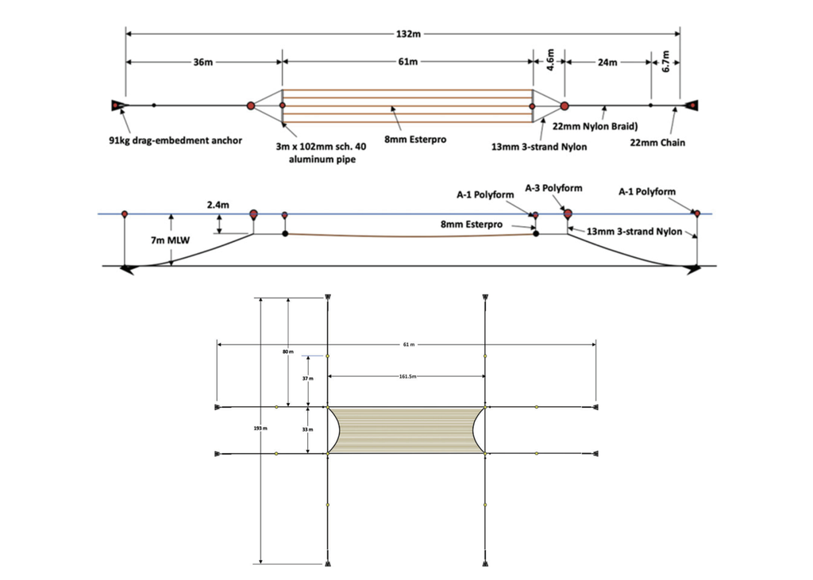

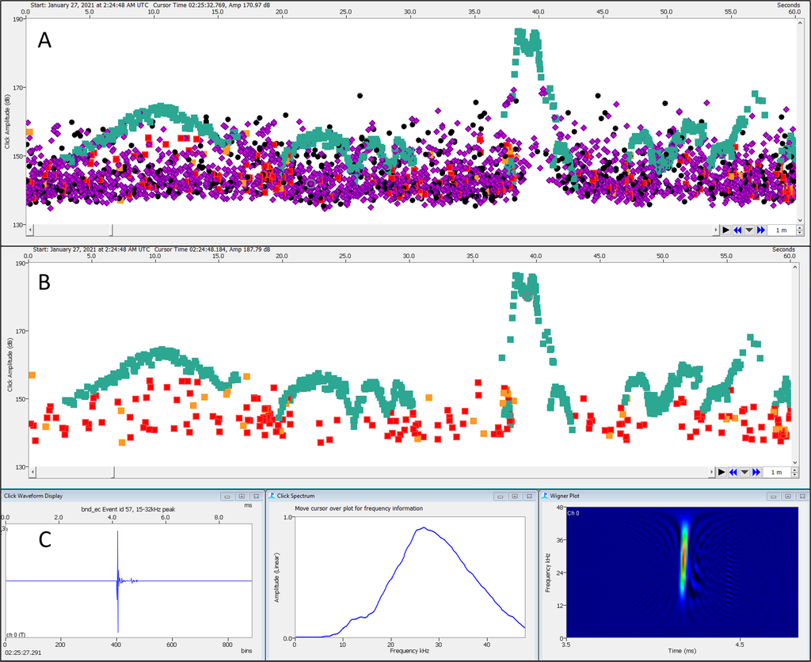

Supplemental Figure S2. Panel A: An example of 1 minute of clicks detected using the PAMGUARD automated click detector. Time is on the x axis, and amplitude in DB is on the y axis. Each dot represents a single detected signal. Purple and black detections are unlikely to be delphinid clicks. Red and organge detections are likely delphinid clicks. Teal detections were manually confirmed to be part of a delphinid click train. Panel B: The same minute of acoustic data, showing only likely detections that are considered likely to be delphinid clicks. Panel C: Acoustic parameters of 1 confirmed delphinid click, showing the wafeform, spectrum, and Wigner plot characteristics used to manually validate clicks.

### Extra text

Within the United States, seaweed has traditionally been consumed by native Alaskans [59] and Hawaiians [60]. It has also been consumed in Maine for over a century [61]. The development of commercial seaweed aquaculture in the U.S. faced multiple challenges in the late 1900s and early 2000s due to complex and geographically variable procedures for gaining aquaculture permits, relatively cheap and available oil and gas, and community-based hesitation about the local effects of nearshore aquaculture [62]. Despite these challenges, the industry has grown since 2010, with most growth concentrated in Maine, Alaska, and Washington [62]. The average annual U.S. commercial production of seaweed 2014-2018 exceeded 21.6 million pounds (~9,800 metric tons), most of which was cultivated within 3 miles of the U.S. shoreline [63], and is considered by NOAA National Marine Fisheries Service to be an important growth sector in the global seafood economy [63], and by the U.S. Department of Energy as promising as a source of biofuel (ARPA-E Macroalgae Research Inspiring Novel Energy Resources (MARINER) program, 2017).